# Time Series: A First Course with Bootstrap Starter

# Lesson 3-7: Integrated Processes

- Sometimes non-stationarity arises in the mean function ${\mathbb E} [ X_t ] = \mu_t$.
- But the mean may not explain all the non-stationarity of a time series.
- *Integrated Processes* are stochastic processes that exhibit a type of non-stationarity.

## Example 3.7.1. Random Walk

- We revisit the *random walk* $\{ X_t \}$, where
  $$X_t = X_{t-1} + Z_t$$
  for $t \geq 1$, and $\{ Z_t \}$ are i.i.d. $(0, \sigma^2)$.
- We can initialize with $X_0 = 0$.
- Note that differencing yields the increment:
  $$(1- B)X_t = Z_t.$$
- Writing the recursion out yields
  $$X_t = X_0 + \sum_{k=1}^t Z_k.$$
- This is a cumulation, hence an *integrated process*.

## Integrated Process

- Suppose that $\{ X_t \}$ is a non-stationary stochastic process such that
  $$(1-B) X_t = Z_t$$
  is stationary. Then it is called an *integrated process*.
- Differencing $1-B$ cancels out the cumulation.

## Example of Integrated Moving Average

- Suppose that $\{ Z_t \}$ is an MA(1), and $X_t= X_{t-1} + Z_t$.
- We simulate a sample path.

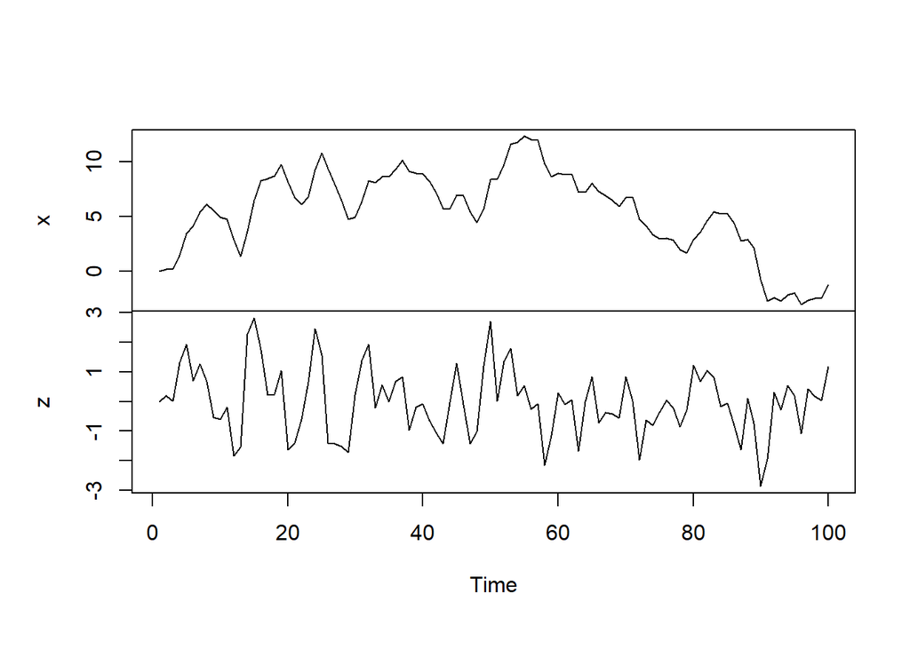

```r
set.seed(777)
n <- 100
eps <- rnorm(n+1)       # Gaussian input
theta <- .8
z <- eps[-1] + theta*eps[-(n+1)]
x <- cumsum(z)
plot(ts(cbind(x,z)),xlab="Time",ylab="",main="")
```

## Example 3.7.3. Unit Root Process

- The AR(1) process $\{ X_t \}$ satisfies
  $$X_t = \phi X_{t-1} + Z_t,$$
  and can be written as
  $$(1 - \phi B) X_t = Z_t.$$
  So when $\phi =1$, the AR(1) is a random walk. The polynomial $1- \phi z$ has root $1/\phi$, and when this root equals one, the root is *unit*. Hence a random walk (and more generally, an integrated process) is sometimes called a *unit root process*.
- Consider a sample path of an AR(1) with high value of $\phi$.

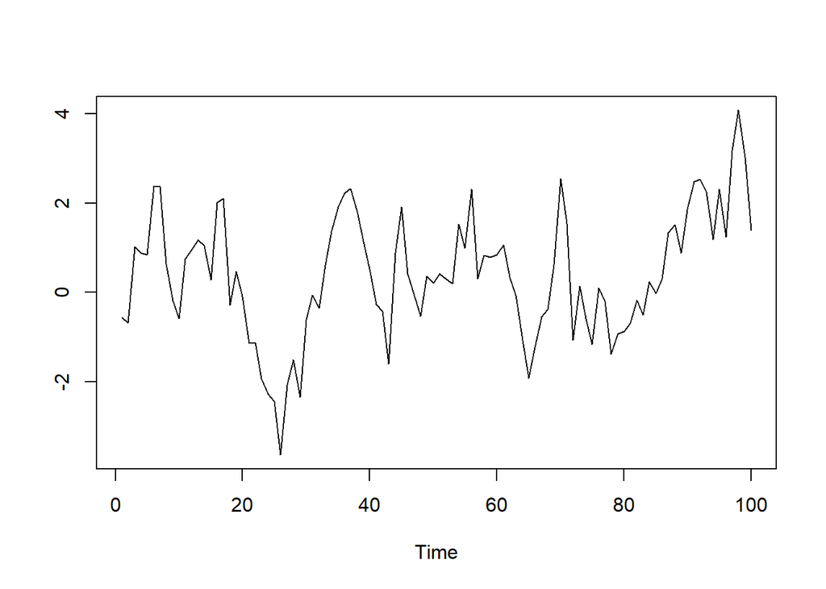

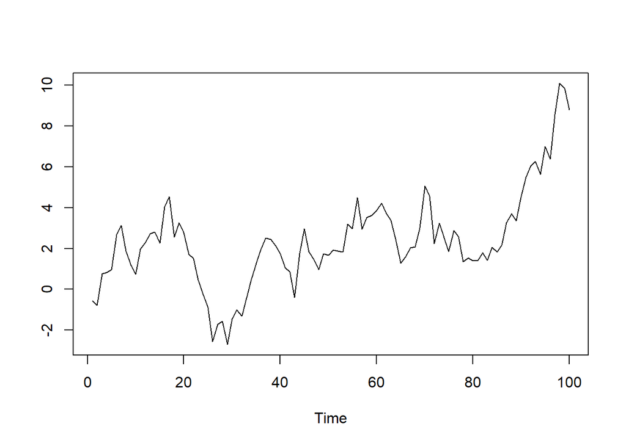

```r
n <- 100
for(i in 1:2)
{
set.seed(123)
z <- rnorm(n)
x <- rep(0,n)
phi <- .80+(i-1)*.199
x0 <- 0
x[1] <- x0 + z[1]
for(t in 2:n) { x[t] <- phi*x[t-1] + z[t] }
plot(ts(x),xlab="Time",ylab="")
}
```